# Reproducible Research

## Course project 1

```r
knitr::opts_chunk$set(echo = TRUE)
```

**Loading and preprocessing the data** Show any code that is needed to :

1. Load the data

```r
read.csv("activity.csv")
activity <- read.csv("activity.csv")
```

Explore data

```r
head(activity)
```

```
##   steps       date interval
## 1    NA 2012-10-01        0
## 2    NA 2012-10-01        5
## 3    NA 2012-10-01       10
## 4    NA 2012-10-01       15
## 5    NA 2012-10-01       20
## 6    NA 2012-10-01       25
```

```r
names(activity)
```

```
## [1] "steps"    "date"     "interval"
```

```r
table(is.na(activity$steps))
```

```
##
## FALSE  TRUE
## 15264  2304
```

```r
class(activity$steps)
```

```
## [1] "integer"
```

```r
class(activity$date)
```

```
## [1] "character"
```

```r
class(activity$interval)
```

```
## [1] "integer"
```

```r
unique(activity$date)
```

```
##  [1] "2012-10-01" "2012-10-02" "2012-10-03" "2012-10-04" "2012-10-05"
##  [6] "2012-10-06" "2012-10-07" "2012-10-08" "2012-10-09" "2012-10-10"
## [11] "2012-10-11" "2012-10-12" "2012-10-13" "2012-10-14" "2012-10-15"
## [16] "2012-10-16" "2012-10-17" "2012-10-18" "2012-10-19" "2012-10-20"
## [21] "2012-10-21" "2012-10-22" "2012-10-23" "2012-10-24" "2012-10-25"
## [26] "2012-10-26" "2012-10-27" "2012-10-28" "2012-10-29" "2012-10-30"
## [31] "2012-10-31" "2012-11-01" "2012-11-02" "2012-11-03" "2012-11-04"
## [36] "2012-11-05" "2012-11-06" "2012-11-07" "2012-11-08" "2012-11-09"
## [41] "2012-11-10" "2012-11-11" "2012-11-12" "2012-11-13" "2012-11-14"
## [46] "2012-11-15" "2012-11-16" "2012-11-17" "2012-11-18" "2012-11-19"
## [51] "2012-11-20" "2012-11-21" "2012-11-22" "2012-11-23" "2012-11-24"
## [56] "2012-11-25" "2012-11-26" "2012-11-27" "2012-11-28" "2012-11-29"
## [61] "2012-11-30"
```

```r
length(unique(activity$date))
```

```
## [1] 61
```

```r
unique(activity$interval)
```

```
##   [1]    0    5   10   15   20   25   30   35   40   45   50   55  100  105  110
##  [16]  115  120  125  130  135  140  145  150  155  200  205  210  215  220  225
##  [31]  230  235  240  245  250  255  300  305  310  315  320  325  330  335  340
##  [46]  345  350  355  400  405  410  415  420  425  430  435  440  445  450  455
##  [61]  500  505  510  515  520  525  530  535  540  545  550  555  600  605  610
##  [76]  615  620  625  630  635  640  645  650  655  700  705  710  715  720  725
##  [91]  730  735  740  745  750  755  800  805  810  815  820  825  830  835  840
## [106]  845  850  855  900  905  910  915  920  925  930  935  940  945  950  955
## [121] 1000 1005 1010 1015 1020 1025 1030 1035 1040 1045 1050 1055 1100 1105 1110
## [136] 1115 1120 1125 1130 1135 1140 1145 1150 1155 1200 1205 1210 1215 1220 1225
## [151] 1230 1235 1240 1245 1250 1255 1300 1305 1310 1315 1320 1325 1330 1335 1340
## [166] 1345 1350 1355 1400 1405 1410 1415 1420 1425 1430 1435 1440 1445 1450 1455
## [181] 1500 1505 1510 1515 1520 1525 1530 1535 1540 1545 1550 1555 1600 1605 1610
## [196] 1615 1620 1625 1630 1635 1640 1645 1650 1655 1700 1705 1710 1715 1720 1725
## [211] 1730 1735 1740 1745 1750 1755 1800 1805 1810 1815 1820 1825 1830 1835 1840
## [226] 1845 1850 1855 1900 1905 1910 1915 1920 1925 1930 1935 1940 1945 1950 1955
## [241] 2000 2005 2010 2015 2020 2025 2030 2035 2040 2045 2050 2055 2100 2105 2110
## [256] 2115 2120 2125 2130 2135 2140 2145 2150 2155 2200 2205 2210 2215 2220 2225
## [271] 2230 2235 2240 2245 2250 2255 2300 2305 2310 2315 2320 2325 2330 2335 2340
## [286] 2345 2350 2355
```

```r
length(unique(activity$interval))
```

```
## [1] 288
```

2. Process / Transform the data (if necessary) into a format suitable for your analysis
1. Make *steps* a numeric variable

```r
activity$steps <- as.numeric(activity$steps)
class(activity$steps)
```

```
## [1] "numeric"
```

2. See if a wide format suits the data better

```r
library(tidyr)
activity_wide <- pivot_wider(activity, names_from=interval, values_from=steps)
head(activity_wide)
```

```
## # A tibble: 6 × 289
##   date     `0`   `5`  `10`  `15`  `20`  `25`  `30`  `35`  `40`  `45`  `50`  `55`
##   <chr>  <dbl> <dbl> <dbl> <dbl> <dbl> <dbl> <dbl> <dbl> <dbl> <dbl> <dbl> <dbl>
## 1 2012-…    NA    NA    NA    NA    NA    NA    NA    NA    NA    NA    NA    NA
## 2 2012-…     0     0     0     0     0     0     0     0     0     0     0     0
## 3 2012-…     0     0     0     0     0     0     0     0     0     0     0     0
## 4 2012-…    47     0     0     0     0     0     0     0     0     0     0     0
## 5 2012-…     0     0     0     0     0     0     0     0     0     0     0     0
## 6 2012-…     0     0     0     0     0     0     0     0     0     0     0     0
## # ℹ 276 more variables: `100` <dbl>, `105` <dbl>, `110` <dbl>, `115` <dbl>,
## #   `120` <dbl>, `125` <dbl>, `130` <dbl>, `135` <dbl>, `140` <dbl>,
## #   `145` <dbl>, `150` <dbl>, `155` <dbl>, `200` <dbl>, `205` <dbl>,
## #   `210` <dbl>, `215` <dbl>, `220` <dbl>, `225` <dbl>, `230` <dbl>,
## #   `235` <dbl>, `240` <dbl>, `245` <dbl>, `250` <dbl>, `255` <dbl>,
## #   `300` <dbl>, `305` <dbl>, `310` <dbl>, `315` <dbl>, `320` <dbl>,
## #   `325` <dbl>, `330` <dbl>, `335` <dbl>, `340` <dbl>, `345` <dbl>, …
```

**What is mean total number of steps taken per day?** For this part of the assignment, you can ignore the missing values in the dataset.

1. Calculate the total number of steps taken per day In the following table, you can find the total number of steps taken on each of the 61 days :

```r
library(dplyr)
activity %>% group_by(date) %>% summarize(sum(steps, na.rm=TRUE))
```

```
## # A tibble: 61 × 2
##    date       `sum(steps, na.rm = TRUE)`
##    <chr>                           <dbl>
##  1 2012-10-01                          0
##  2 2012-10-02                        126
##  3 2012-10-03                      11352
##  4 2012-10-04                      12116
##  5 2012-10-05                      13294
##  6 2012-10-06                      15420
##  7 2012-10-07                      11015
##  8 2012-10-08                          0
##  9 2012-10-09                      12811
## 10 2012-10-10                       9900
## # ℹ 51 more rows
```

```r
step_day_table <- activity %>% group_by(date) %>% summarize(step_day = sum(steps, na.rm=TRUE))
head(step_day_table)
```

```
## # A tibble: 6 × 2
##   date       step_day
##   <chr>         <dbl>
## 1 2012-10-01        0
## 2 2012-10-02      126
## 3 2012-10-03    11352
## 4 2012-10-04    12116
## 5 2012-10-05    13294
## 6 2012-10-06    15420
```

```r
step_day <- step_day_table$step_day
step_day
```

```
##  [1]     0   126 11352 12116 13294 15420 11015     0 12811  9900 10304 17382
## [13] 12426 15098 10139 15084 13452 10056 11829 10395  8821 13460  8918  8355
## [25]  2492  6778 10119 11458  5018  9819 15414     0 10600 10571     0 10439
## [37]  8334 12883  3219     0     0 12608 10765  7336     0    41  5441 14339
## [49] 15110  8841  4472 12787 20427 21194 14478 11834 11162 13646 10183  7047
## [61]     0
```

2. Make a histogram of the total number of steps taken each day

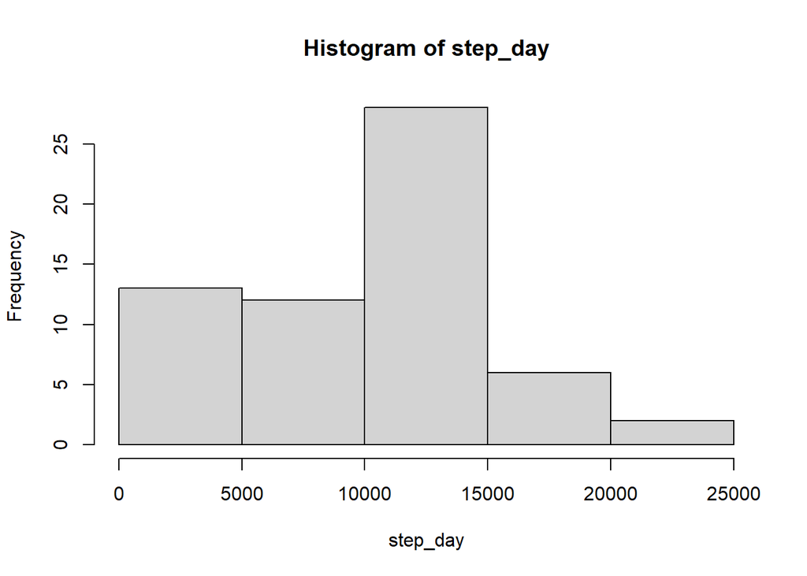

```r
hist(step_day)
```

3. Calculate and report the mean and median of the total number of steps taken per day

```r
mean(step_day)
```

```
## [1] 9354.23
```

```r
median(step_day)
```

```
## [1] 10395
```

**What is the average daily activity pattern?**

1. Make a time series plot of the 5-minute interval and the average number of steps taken, averaged across all days

```r
activity %>% group_by(interval) %>% summarize(mean(steps, na.rm=TRUE))
```

```
## # A tibble: 288 × 2
##    interval `mean(steps, na.rm = TRUE)`
##       <int>                       <dbl>
##  1        0                      1.72
##  2        5                      0.340
##  3       10                      0.132
##  4       15                      0.151
##  5       20                      0.0755
##  6       25                      2.09
##  7       30                      0.528
##  8       35                      0.868
##  9       40                      0
## 10       45                      1.47
## # ℹ 278 more rows
```

```r
step_interval_table <- activity %>% group_by(interval) %>% summarize(step_interval = mean(steps, na.rm=TRUE))
head(step_interval_table)
```

```
## # A tibble: 6 × 2
##   interval step_interval
##      <int>         <dbl>
## 1        0        1.72
## 2        5        0.340
## 3       10        0.132
## 4       15        0.151
## 5       20        0.0755
## 6       25        2.09
```

```r
step_interval <- step_interval_table$step_interval
step_interval
```

```
##   [1]   1.7169811   0.3396226   0.1320755   0.1509434   0.0754717   2.0943396
##   [7]   0.5283019   0.8679245   0.0000000   1.4716981   0.3018868   0.1320755
##  [13]   0.3207547   0.6792453   0.1509434   0.3396226   0.0000000   1.1132075
##  [19]   1.8301887   0.1698113   0.1698113   0.3773585   0.2641509   0.0000000
##  [25]   0.0000000   0.0000000   1.1320755   0.0000000   0.0000000   0.1320755
##  [31]   0.0000000   0.2264151   0.0000000   0.0000000   1.5471698   0.9433962
##  [37]   0.0000000   0.0000000   0.0000000   0.0000000   0.2075472   0.6226415
##  [43]   1.6226415   0.5849057   0.4905660   0.0754717   0.0000000   0.0000000
##  [49]   1.1886792   0.9433962   2.5660377   0.0000000   0.3396226   0.3584906
##  [55]   4.1132075   0.6603774   3.4905660   0.8301887   3.1132075   1.1132075
##  [61]   0.0000000   1.5660377   3.0000000   2.2452830   3.3207547   2.9622642
##  [67]   2.0943396   6.0566038  16.0188679  18.3396226  39.4528302  44.4905660
##  [73]  31.4905660  49.2641509  53.7735849  63.4528302  49.9622642  47.0754717
##  [79]  52.1509434  39.3396226  44.0188679  44.1698113  37.3584906  49.0377358
##  [85]  43.8113208  44.3773585  50.5094340  54.5094340  49.9245283  50.9811321
```

[output cut: 33 more lines]

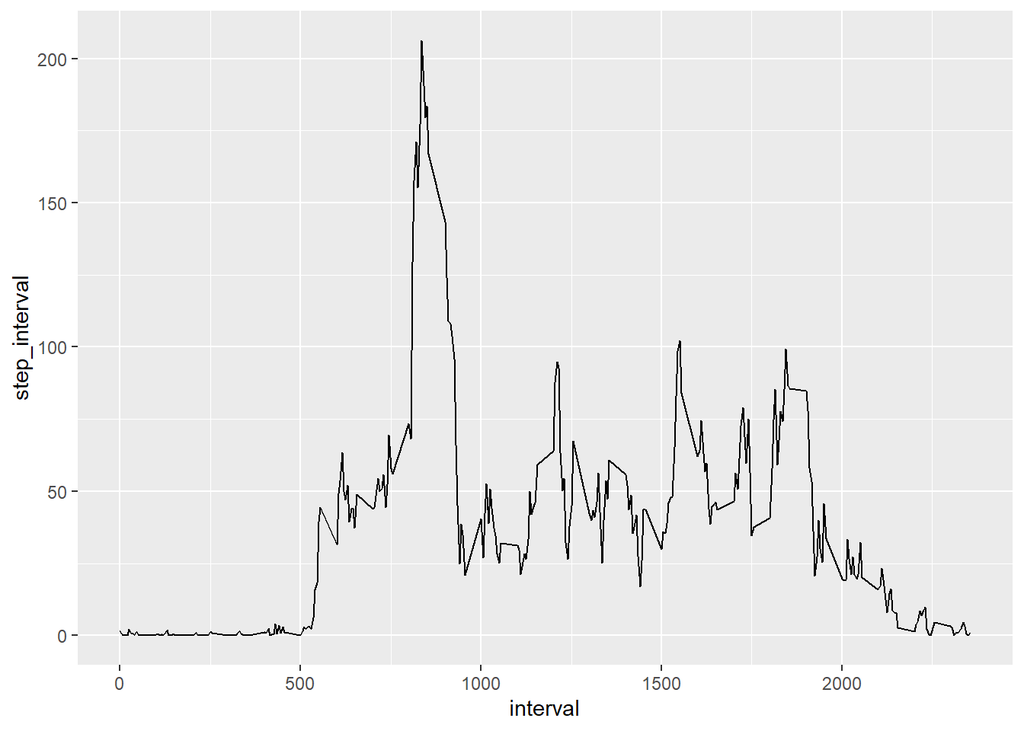

```r
library(ggplot2)
timeseries <- ggplot(step_interval_table, aes(x=interval, y=step_interval))+geom_line()
timeseries
```

2. Which 5-minute interval, on average across all the days in the dataset, contains the maximum number of steps?

```r
max(step_interval)
```

```
## [1] 206.1698
```

```r
subset(step_interval_table, step_interval == max(step_interval))
```

```
## # A tibble: 1 × 2
##   interval step_interval
##      <int>         <dbl>
## 1      835          206.
```

The 835 interval contains the maximum average number of steps.

**Imputing missing values**

1. Calculate and report the total number of missing values in the dataset.

```r
table(is.na(activity$steps))
```

```
##
## FALSE  TRUE
## 15264  2304
```

The total number of missing values is 2304.

2. Devise a strategy for filling in all the missing values in the dataset (e.g. mean for the 5-min interval)
3. Create a new dataset that is equal to the original dataset but with the missing data filled in.

```r
library(dplyr)
library(zoo)
activity_new <- activity

activity_new <- activity_new %>% group_by(interval) %>% mutate_at("steps", na.aggregate, FUN=mean)
head(activity_new)
```

```
## # A tibble: 6 × 3
## # Groups:   interval [6]
##    steps date       interval
##    <dbl> <chr>         <int>
## 1 1.72   2012-10-01        0
## 2 0.340  2012-10-01        5
## 3 0.132  2012-10-01       10
## 4 0.151  2012-10-01       15
## 5 0.0755 2012-10-01       20
## 6 2.09   2012-10-01       25
```

```r
table(is.na(activity_new$steps))
```

```
##
## FALSE
## 17568
```

4. Make a histogram of the total number of steps taken each day and calculate and report the mean and median total numer of steps taken per day. Do these values differ from the estimates from the first part of the assignment? What is the impact of imputing missing data on the estimates of the total daily number of steps?

```r
activity_new %>% group_by(date) %>% summarize(sum(steps))
```

```
## # A tibble: 61 × 2
##    date       `sum(steps)`
##    <chr>             <dbl>
##  1 2012-10-01       10766.
##  2 2012-10-02         126
##  3 2012-10-03       11352
##  4 2012-10-04       12116
##  5 2012-10-05       13294
##  6 2012-10-06       15420
##  7 2012-10-07       11015
##  8 2012-10-08       10766.
##  9 2012-10-09       12811
## 10 2012-10-10        9900
## # ℹ 51 more rows
```

```r
step_day_table_new <- activity_new %>% group_by(date) %>% summarize(step_day_new = sum(steps))
head(step_day_table_new)
```

```
## # A tibble: 6 × 2
##   date       step_day_new
##   <chr>             <dbl>
## 1 2012-10-01       10766.
## 2 2012-10-02         126
## 3 2012-10-03       11352
## 4 2012-10-04       12116
## 5 2012-10-05       13294
## 6 2012-10-06       15420
```

```r
step_day_new <- step_day_table_new$step_day_new
step_day_new
```

```
##  [1] 10766.19   126.00 11352.00 12116.00 13294.00 15420.00 11015.00 10766.19
##  [9] 12811.00  9900.00 10304.00 17382.00 12426.00 15098.00 10139.00 15084.00
## [17] 13452.00 10056.00 11829.00 10395.00  8821.00 13460.00  8918.00  8355.00
## [25]  2492.00  6778.00 10119.00 11458.00  5018.00  9819.00 15414.00 10766.19
## [33] 10600.00 10571.00 10766.19 10439.00  8334.00 12883.00  3219.00 10766.19
## [41] 10766.19 12608.00 10765.00  7336.00 10766.19    41.00  5441.00 14339.00
## [49] 15110.00  8841.00  4472.00 12787.00 20427.00 21194.00 14478.00 11834.00
## [57] 11162.00 13646.00 10183.00  7047.00 10766.19
```

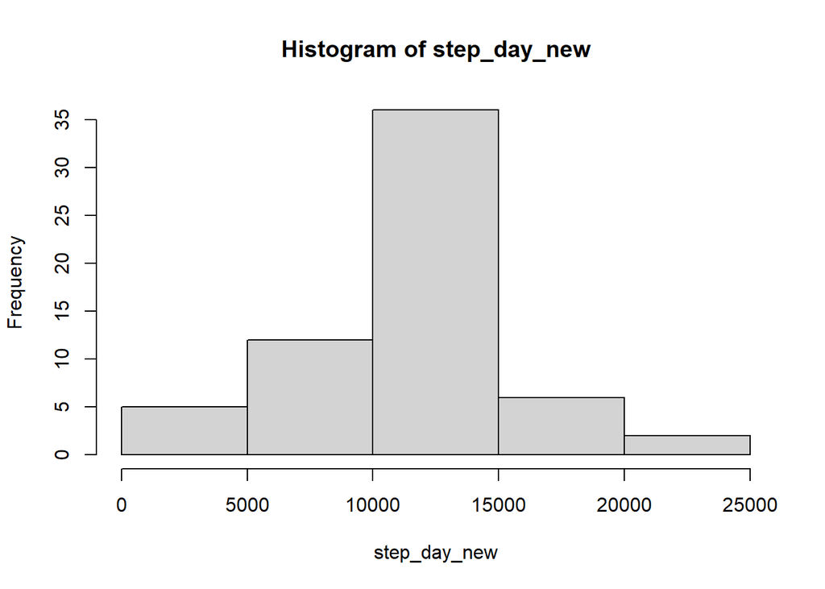

```r
hist(step_day_new)
```

```r
mean(step_day_new)
```

```
## [1] 10766.19
```

```r
median(step_day_new)
```

```
## [1] 10766.19
```

The old mean was 9354.23 and became 10766.19 The old median was 10395 and became 10766.19 Imputing missing data changes the estimates of the total daily number of steps, and in this case causes a possible overestimation of the effect.

**Are there differences in activity patterns between weekdays and weekends?**

1. Create a new factor variable in the dataset with two levels - “weekday” and “weekend” indicating whether a given date is a weekday or weekend day.

```r
activity_new$date <- as.Date(activity_new$date)
class(activity_new$date)
```

```
## [1] "Date"
```

```r
head(activity_new$date)
```

```
## [1] "2012-10-01" "2012-10-01" "2012-10-01" "2012-10-01" "2012-10-01"
## [6] "2012-10-01"
```

```r
activity_new$weekday <- weekdays(activity_new$date)

activity_new %>% mutate(weekday2 = case_when(weekday==c("maandag", "dinsdag", "woensdag", "donderdag", "vrijdag")~'weekday', weekday==c("zaterdag", "zondag")~'weekend'))
```

```
## # A tibble: 17,568 × 5
## # Groups:   interval [288]
##     steps date       interval weekday weekday2
##     <dbl> <date>        <int> <chr>   <chr>
##  1 1.72   2012-10-01        0 maandag weekday
##  2 0.340  2012-10-01        5 maandag weekday
##  3 0.132  2012-10-01       10 maandag weekday
##  4 0.151  2012-10-01       15 maandag weekday
##  5 0.0755 2012-10-01       20 maandag weekday
##  6 2.09   2012-10-01       25 maandag weekday
##  7 0.528  2012-10-01       30 maandag weekday
##  8 0.868  2012-10-01       35 maandag weekday
##  9 0      2012-10-01       40 maandag weekday
## 10 1.47   2012-10-01       45 maandag weekday
## # ℹ 17,558 more rows
```

```r
activity_new2 <- activity_new %>% mutate(weekday2 = case_when(weekday==c("maandag", "dinsdag", "woensdag", "donderdag", "vrijdag")~'weekday', weekday==c("zaterdag", "zondag")~'weekend'))
head(activity_new2)
```

```
## # A tibble: 6 × 5
## # Groups:   interval [6]
##    steps date       interval weekday weekday2
##    <dbl> <date>        <int> <chr>   <chr>
## 1 1.72   2012-10-01        0 maandag weekday
## 2 0.340  2012-10-01        5 maandag weekday
## 3 0.132  2012-10-01       10 maandag weekday
## 4 0.151  2012-10-01       15 maandag weekday
## 5 0.0755 2012-10-01       20 maandag weekday
## 6 2.09   2012-10-01       25 maandag weekday
```

2. Make a panel plot containing a time series plot of the 5-minute interval and average number of steps taken, averaged accross all weekday or weekend days.

```r
activity_new2 %>% group_by(interval, weekday2) %>% summarize(mean(steps))
```

```
## # A tibble: 864 × 3
## # Groups:   interval [288]
##    interval weekday2 `mean(steps)`
##       <int> <chr>            <dbl>
##  1        0 weekday         5.04
##  2        0 weekend         0.215
##  3        0 <NA>            1.22
##  4        5 weekday         0.0679
##  5        5 weekend         0.0425
##  6        5 <NA>            0.458
##  7       10 weekday         0.0264
##  8       10 weekend         0.0165
##  9       10 <NA>            0.178
## 10       15 weekday         0.0302
## # ℹ 854 more rows
```

```r
step_interval_table2 <- activity_new2 %>% group_by(interval, weekday2) %>% summarize(step_interval2 = mean(steps))
head(step_interval_table2)
```

```
## # A tibble: 6 × 3
## # Groups:   interval [2]
##   interval weekday2 step_interval2
##      <int> <chr>             <dbl>
## 1        0 weekday          5.04
## 2        0 weekend          0.215
## 3        0 <NA>             1.22
## 4        5 weekday          0.0679
## 5        5 weekend          0.0425
## 6        5 <NA>             0.458
```

```r
step_interval2 <- step_interval_table2$step_interval2
step_interval2
```

[output not shown]

[output cut: 158 more lines]

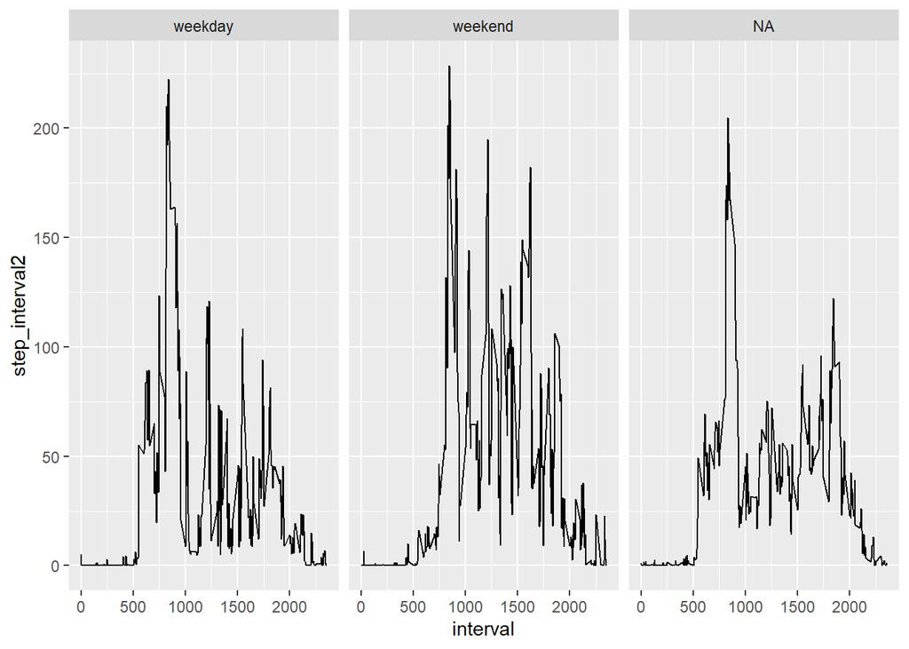

```r
timeseries2 <- ggplot(step_interval_table2, aes(x=interval, y=step_interval2))+geom_line()
timeseries2+facet_grid(.~weekday2)
```

Unfortunately, I was not able to fix the problem with the NA for the date being a weekday or weekend day.